# Students Math Score Predicction Model

# 1 Introduction

> This exercise aims to fit a model able to predict the math score from a sample of 1000 students based on sociodemographics features, and other quantitative metrics such us the results from other tests. For this popouse we obtain the dataset from kaggle [link](https://www.kaggle.com/spscientist/students-performance-in-exams).

## 1.1 Excercise Premises

- We want to predict the column ‘math score’ using Neural Networks.
- We must use a Deep Learning framework for this exercise as Keras.
- We should split the dataset in train/test to verify your results.

# 2 Loading Students Dataset

We start loading StudentsPerfomance dataset from the defined working path.

```r
#Setting working path
setwd("/home/bjur/R/Students_Performance_Model/Students_Performance")
filesp2 <- "StudentsPerformance.csv"
students_data = read.csv(filesp2)
```

# 3 Student Dataset at glance

## 3.1 Data Exploration Block

### 3.1.1 Descriptive Exploration

> With the porpuse to understand the dataset we call the following R descriptive functions, in order to understand the variables types (Categorical, Numeric),frecuencies for categorical fatures and main statistics for the continuous variables.

```r
str(students_data)
```

```
## 'data.frame':    1000 obs. of  8 variables:
##  $ gender                     : Factor w/ 2 levels "female","male": 1 1 1 2 2 1 1 2 2 1 ...
##  $ race.ethnicity             : Factor w/ 5 levels "group A","group B",..: 2 3 2 1 3 2 2 2 4 2 ...
##  $ parental.level.of.education: Factor w/ 6 levels "associate's degree",..: 2 5 4 1 5 1 5 5 3 3 ...
##  $ lunch                      : Factor w/ 2 levels "free/reduced",..: 2 2 2 1 2 2 2 1 1 1 ...
##  $ test.preparation.course    : Factor w/ 2 levels "completed","none": 2 1 2 2 2 2 1 2 1 2 ...
##  $ math.score                 : int  72 69 90 47 76 71 88 40 64 38 ...
##  $ reading.score              : int  72 90 95 57 78 83 95 43 64 60 ...
##  $ writing.score              : int  74 88 93 44 75 78 92 39 67 50 ...
```

```r
head(students_data)
```

```
##   gender race.ethnicity parental.level.of.education        lunch
## 1 female        group B           bachelor's degree     standard
## 2 female        group C                some college     standard
## 3 female        group B             master's degree     standard
## 4   male        group A          associate's degree free/reduced
## 5   male        group C                some college     standard
## 6 female        group B          associate's degree     standard
##   test.preparation.course math.score reading.score writing.score
## 1                    none         72            72            74
## 2               completed         69            90            88
## 3                    none         90            95            93
## 4                    none         47            57            44
## 5                    none         76            78            75
## 6                    none         71            83            78
```

```r
summary(students_data)
```

```
##     gender    race.ethnicity     parental.level.of.education
##  female:518   group A: 89    associate's degree:222
##  male  :482   group B:190    bachelor's degree :118
##               group C:319    high school       :196
##               group D:262    master's degree   : 59
##               group E:140    some college      :226
##                              some high school  :179
##           lunch     test.preparation.course   math.score
##  free/reduced:355   completed:358           Min.   :  0.00
##  standard    :645   none     :642           1st Qu.: 57.00
##                                             Median : 66.00
##                                             Mean   : 66.09
##                                             3rd Qu.: 77.00
##                                             Max.   :100.00
##  reading.score    writing.score
##  Min.   : 17.00   Min.   : 10.00
##  1st Qu.: 59.00   1st Qu.: 57.75
##  Median : 70.00   Median : 69.00
##  Mean   : 69.17   Mean   : 68.05
##  3rd Qu.: 79.00   3rd Qu.: 79.00
##  Max.   :100.00   Max.   :100.00
```

### 3.1.2 Some Visuals

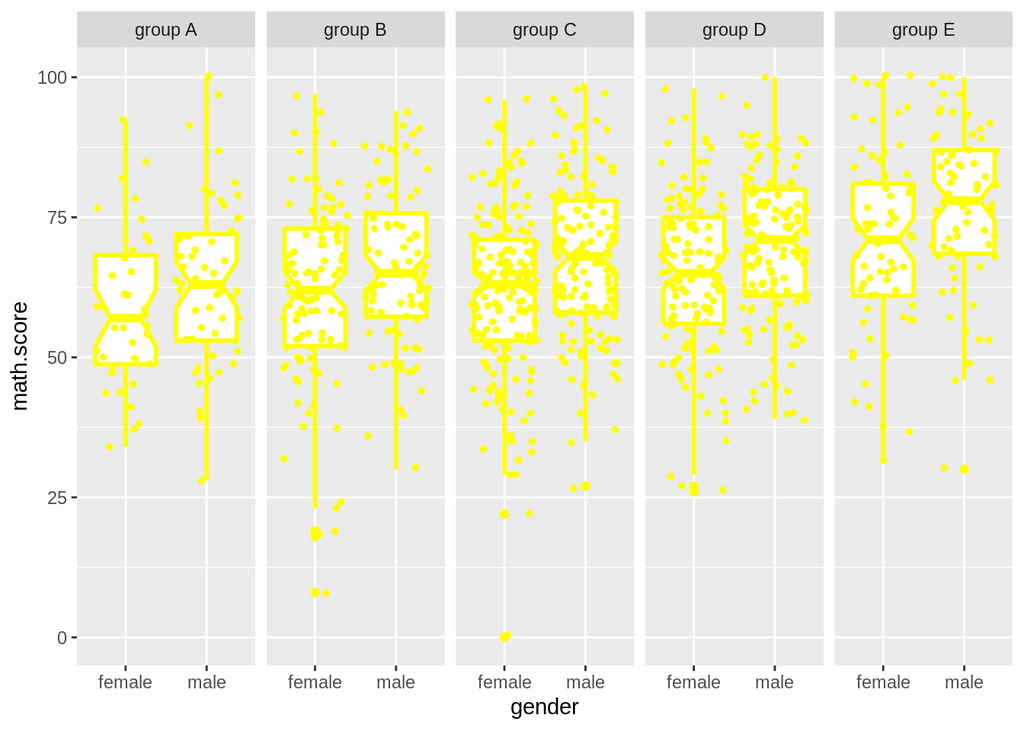

```r
ggplot(students_data, aes(x = gender, y = math.score)) +geom_boxplot(colour="yellow", fill = "white",
                                                                      size = 1, notch = TRUE)+ geom_jitter(colour = "yellow",size=1)+ facet_grid(~ race.ethnicity)
```

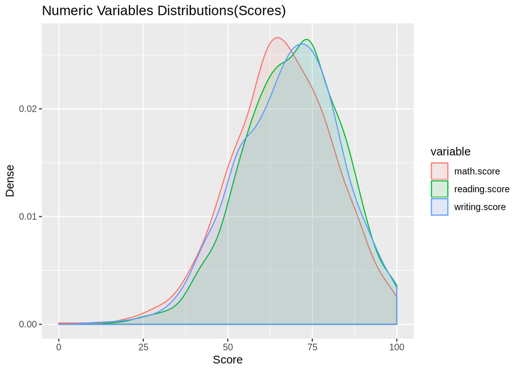

```r
students_data[,c("math.score","reading.score","writing.score")]%>%
melt()%>%
      ggplot(aes(value, fill= variable, colour=variable))+ geom_density(alpha = 0.1)+
          labs(title="Numeric Variables Distributions(Scores)") +
              labs(x="Score", y="Dense")
```

**net/net**:A light visual exploration helps to understand quickly for example how continous features distribution overlaps target variable, or higher scores for males within all the ethnics universe.

# 4 Uni/Multivariate Analysis Block

> This block aims to understand the behaviour of the target variable explained from the other set of variables (features) as predictors, in standalone basis, as subsets or as a whole. For that task we measure the relevance and the explanatory capacity over the math score variance. This block is strictly descriptive as the training of the model through deep learning technics aims to fit by itselt all this depencencies under the minimization of the loss and error, or maximization of the accuracy (this last in case of a classification model).

## 4.1 Univariate

We study all the posible linear models from the set of features. As a premise R transforms all categorical variables as dummies inputs modelling all its posibble values(commoly called one hot encoding).

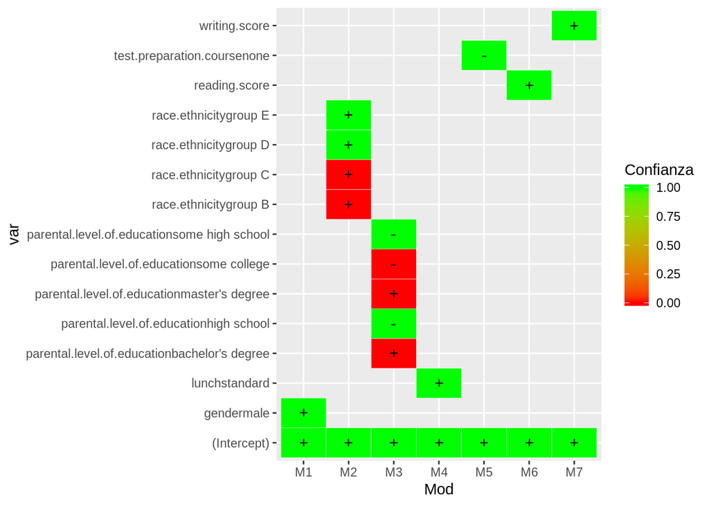

```r
ggplot(Models,aes(x =Mod ,y = var,fill = Confianza)) +
  geom_tile(colour="white") + geom_text(aes(label=Aporte))+
  scale_fill_gradient(low = "red", high = "green")
```

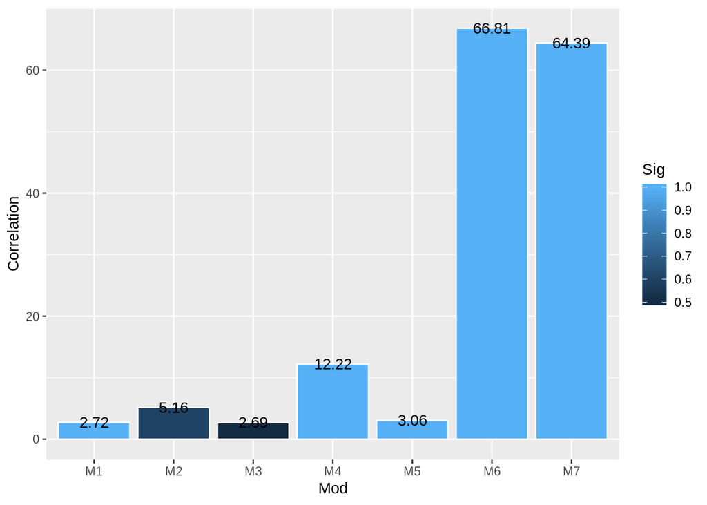

```r
Models %>%
    group_by(Mod) %>%
    summarise(Correlation = round(mean(R)*100,2), Sig = mean(Confianza)) %>%
    ggplot(aes(x =Mod ,y =Correlation, fill= Sig )) + geom_bar(colour="white",stat = "identity") + geom_text(aes(label=Correlation))
```

**net/net**: All the cuantitative features explains under at least 95% confidence partly the variance of the model.From the categorical features block (as dummies) we observe how the gender male, some ethnics, even an standart lunch (Vs free reduced) type explains with high confidence levels better math scores within the students records, against a none preparation course , or even a poor parents education level drives a worse math scores. Individually the categorical features explain poorly the math score variance.As we previously shily noticed in the visual exploration, the continous features such us reading and writting scores explanins better math scores.

## 4.2 Multivariate Analisys Block

We study some multivariate regression models set of features, and the whole features set, with the purpose to understand cross impact of the features, or colineality of the numeric features.

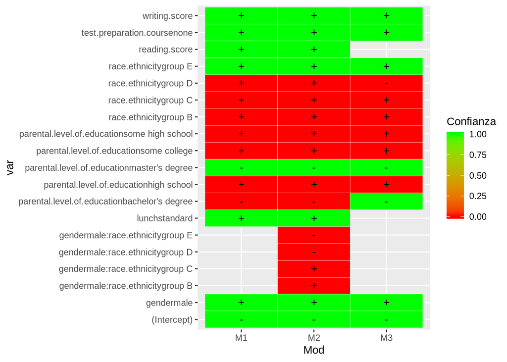

```r
ggplot(Models,aes(x =Mod ,y = var,fill = Confianza)) +
  geom_tile(colour="white") + geom_text(aes(label=Aporte))+
  scale_fill_gradient(low = "red", high = "green")
```

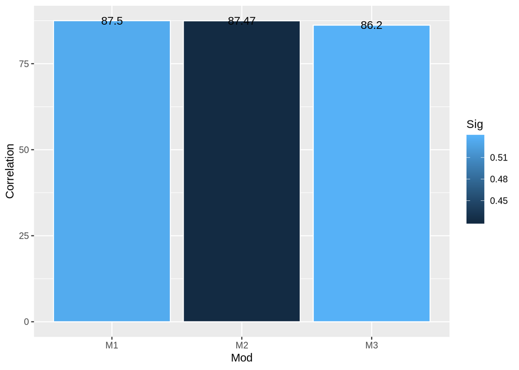

```r
Models %>%
    group_by(Mod) %>%
    summarise(Correlation = round(mean(R)*100,2), Sig = mean(Confianza)) %>%
    ggplot(aes(x =Mod ,y =Correlation, fill= Sig )) + geom_bar(colour="white",stat = "identity") + geom_text(aes(label=Correlation))
```

```r
#Model Summary
modeloMul1=lm(math.score ~ ., data = students_data)
summary(modeloMul1)
```

```
##
## Call:
## lm(formula = math.score ~ ., data = students_data)
##
## Residuals:
##      Min       1Q   Median       3Q      Max
## -17.4995  -3.6824   0.1218   3.3932  14.1178
##
## Coefficients:
##                                               Estimate Std. Error t value
## (Intercept)                                  -11.60449    1.24479  -9.322
## gendermale                                    13.24045    0.37193  35.599
## race.ethnicitygroup B                          0.83537    0.69230   1.207
## race.ethnicitygroup C                          0.17823    0.64899   0.275
## race.ethnicitygroup D                          0.09840    0.67014   0.147
## race.ethnicitygroup E                          5.07770    0.73714   6.888
## parental.level.of.educationbachelor's degree  -1.04690    0.61571  -1.700
## parental.level.of.educationhigh school         0.56773    0.53518   1.061
## parental.level.of.educationmaster's degree    -1.85607    0.79324  -2.340
## parental.level.of.educationsome college        0.40026    0.50814   0.788
## parental.level.of.educationsome high school    0.55216    0.54989   1.004
## lunchstandard                                  3.21271    0.37420   8.585
## test.preparation.coursenone                    3.50227    0.39658   8.831
## reading.score                                  0.26351    0.04205   6.266
## writing.score                                  0.70156    0.04352  16.120
##                                              Pr(>|t|)
## (Intercept)                                   < 2e-16 ***
## gendermale                                    < 2e-16 ***
## race.ethnicitygroup B                          0.2279
## race.ethnicitygroup C                          0.7837
## race.ethnicitygroup D                          0.8833
## race.ethnicitygroup E                        1.00e-11 ***
## parental.level.of.educationbachelor's degree   0.0894 .
## parental.level.of.educationhigh school         0.2890
## parental.level.of.educationmaster's degree     0.0195 *
## parental.level.of.educationsome college        0.4311
## parental.level.of.educationsome high school    0.3156
## lunchstandard                                 < 2e-16 ***
## test.preparation.coursenone                   < 2e-16 ***
## reading.score                                5.52e-10 ***
## writing.score                                 < 2e-16 ***
## ---
## Signif. codes:  0 '***' 0.001 '**' 0.01 '*' 0.05 '.' 0.1 ' ' 1
##
## Residual standard error: 5.362 on 985 degrees of freedom
## Multiple R-squared:  0.8767, Adjusted R-squared:  0.875
## F-statistic: 500.3 on 14 and 985 DF,  p-value: < 2.2e-16
```

# 5 Model Development Block

For the model development we will develop two different models, one regression model with a continous output “math score” in the range of 1-100, and a binary classificator aiming to classify students between those who passes and not according to a threshold of 50 points, both according to the features provided.

## 5.1 Regression Model Development Block

#### 5.1.0.1 Data Formating and New Sinthetic Data Creation

In this section we will summarize numeric scorings(writting and reading) transforming those variables to percentiles of their owns distribution, for further predictions we should do a t-test in order to understand samples independences.

```r
students_dataB <- students_data %>%
  mutate(reading.score.percentile = round(percent_rank(reading.score)*10),writing.score.percentile = round(percent_rank(writing.score)*10))
students_dataB$reading.score<-NULL
students_dataB$writing.score<-NULL
table(students_data$reading.score.percentile)
```

```
## < table of extent 0 >
```

```r
table(students_data$reading.score.percentile)
```

```
## < table of extent 0 >
```

#### 5.1.0.2 Data Splitting Block

Although keras ML library imported already includes the dataset splitting functions during the network trainning procesess, in order to carry out further validation analysis we wil split the dataset despite of its small size.

```r
index <- sample(1:nrow(students_dataB),round(0.8*nrow(students_dataB)))
train <- students_dataB[index,]
test <- students_dataB[-index,]

#Train Model Input Formating
x_train <- train[, -which(names(train) %in% c("math.score"))]
y_train<-train$math.score
x_train_mtrx <-  data.matrix(dummy.data.frame(x_train))
y_train_mtrx <-data.matrix(y_train)

#Test Model Input Formating

x_test <- test[, -which(names(test) %in% c("math.score"))]
y_test<-test$math.score
x_test_mtrx <-  data.matrix(dummy.data.frame(x_test))
y_test_mtrx <-data.matrix(y_test)
```

We compile the network with the mse(mean square error) function, as the loss function very common in this kind of supervised regression problems as the difference between the network predictions and the given targets.

### 5.1.1 Models Selection(Keras)

```r
#Model design
model <- keras_model_sequential() %>%
  layer_dense(units = 300, activation = "relu",
              input_shape = dim(x_train_mtrx)[[2]]) %>%
  layer_dense(units = 30, activation = "relu") %>%
  layer_dense(units = 30, activation = "relu") %>%
  layer_dense(units = 1)

#Compilation
model %>% compile(
  optimizer = "rmsprop",
  loss = "mse",
  metrics = c("mae")
)

#Train
history <- model %>% fit(
  x_train_mtrx, y_train_mtrx,
  epochs = 30, batch_size = 128,
  validation_split = 0.2
)


summary(model)
```

```
## ___________________________________________________________________________
## Layer (type)                     Output Shape                  Param #
## ===========================================================================
## dense_1 (Dense)                  (None, 300)                   6000
## ___________________________________________________________________________
## dense_2 (Dense)                  (None, 30)                    9030
## ___________________________________________________________________________
## dense_3 (Dense)                  (None, 30)                    930
## ___________________________________________________________________________
## dense_4 (Dense)                  (None, 1)                     31
## ===========================================================================
## Total params: 15,991
## Trainable params: 15,991
## Non-trainable params: 0
## ___________________________________________________________________________
```

### 5.1.2 Evaluation

We evaluate the model as the MAE(Mean square Error) absolute level and relative between the test and the train samples in order to undesrtand overfitting issues.

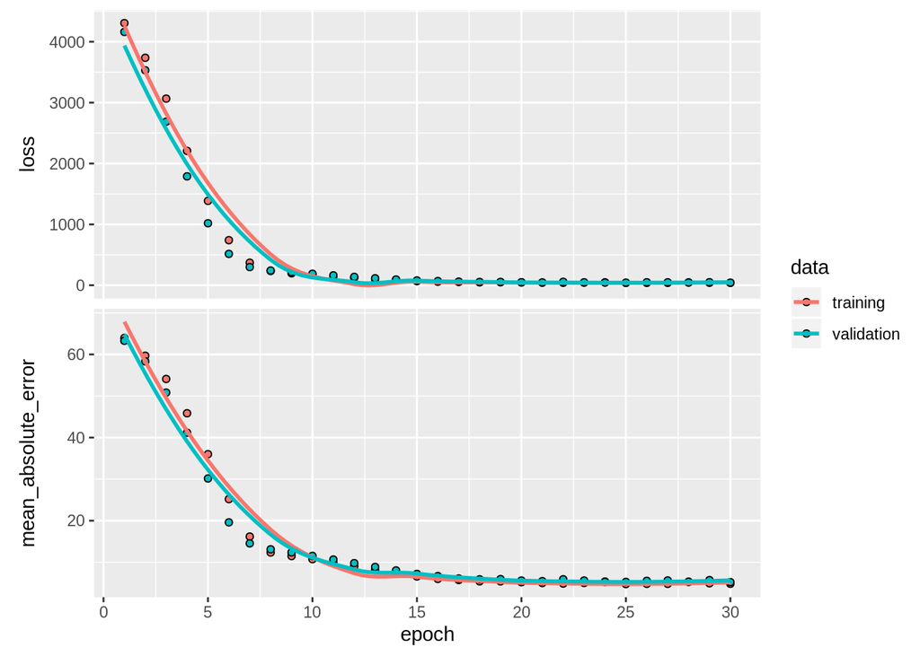

```
## $loss
## [1] 38.05256
##
## $mean_absolute_error
## [1] 4.799341
```

```
## $loss
## [1] 36.83843
##
## $mean_absolute_error
## [1] 4.843872
```

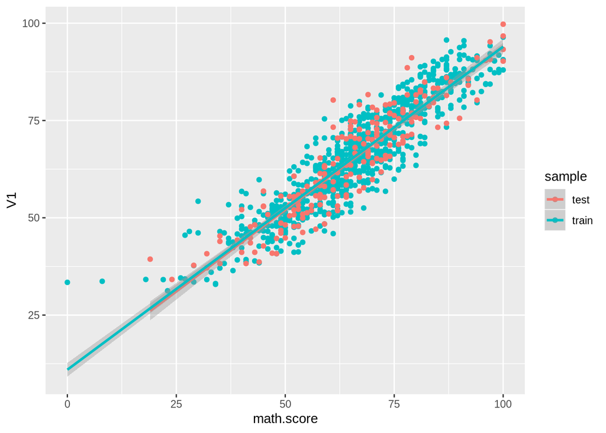

**net/net* We observe agil error convergence of the train and test samples in few epochs to low MAE (Mean average Error) levels confirming a good perfomance traning, therefore without overfitting issues as Test MAE is analgous to the Trainning MAE, an in the close to 5 math score points in average (Vs a math score media of 66 so less than 10%).

## 5.2 Binary Classification Model

### 5.2.1 Data Formating and sinthetic creation

We create a new output binary variable for training and testing called “pass” that models if a record has pass maths according to an score threshold of 50 points.

We incude the independence test regarding the pass variable, through a chi2 test for each category(Against pass target). If we t reject the indepence test the feature is represented with a green colour in the bar plot above. Also we include as a height of the bar how taht categori influences the pass, so if a bar height is above the mean(represented with the red line), that category has an influence over the math score.

```
## integer(0)
```

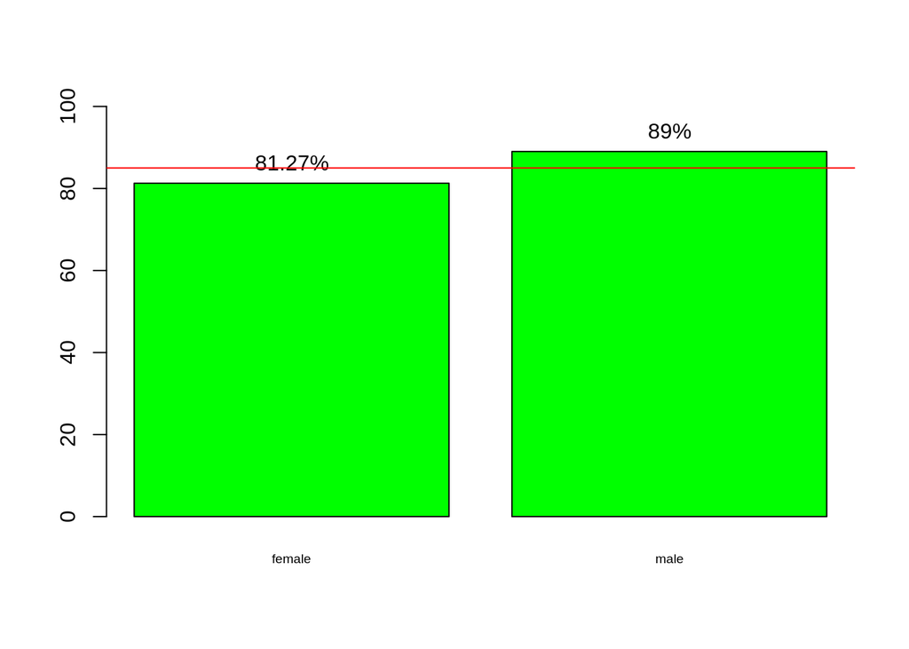

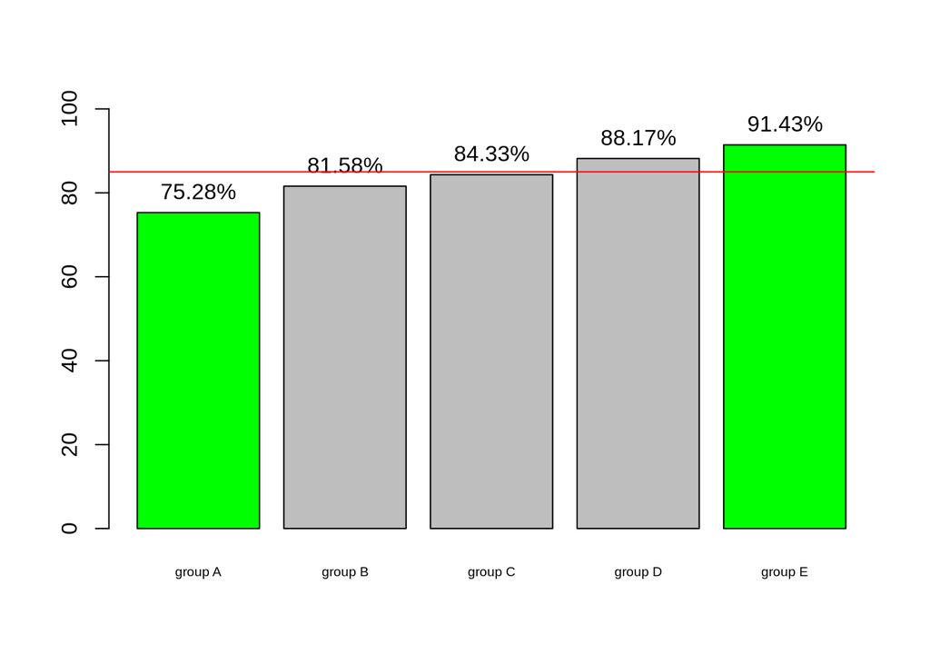

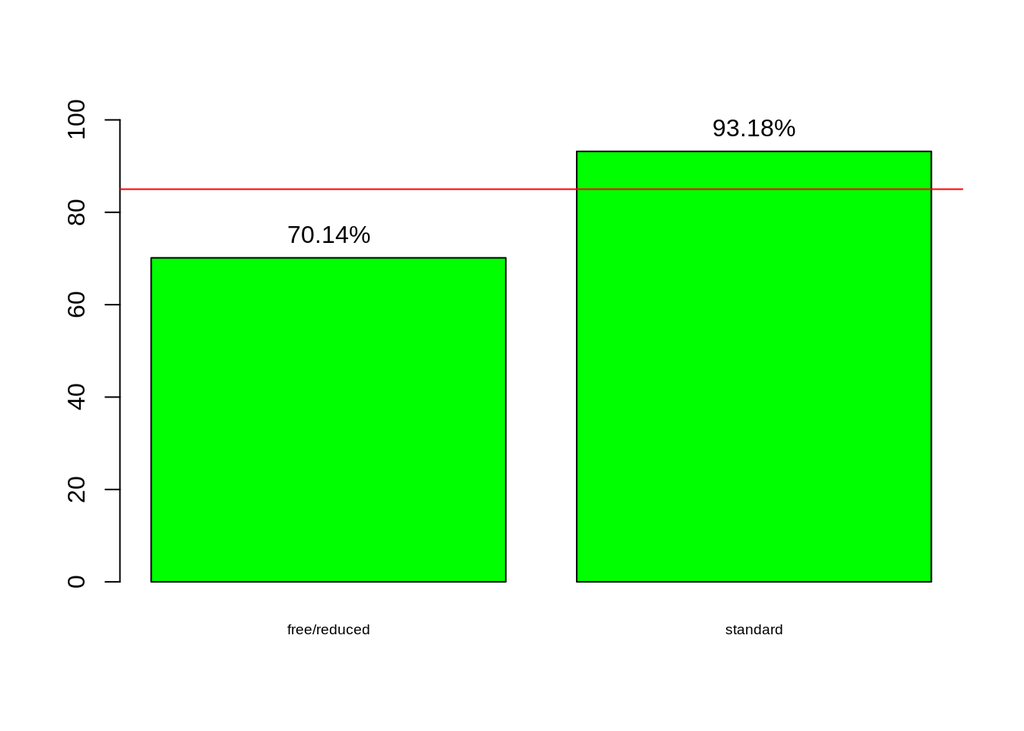

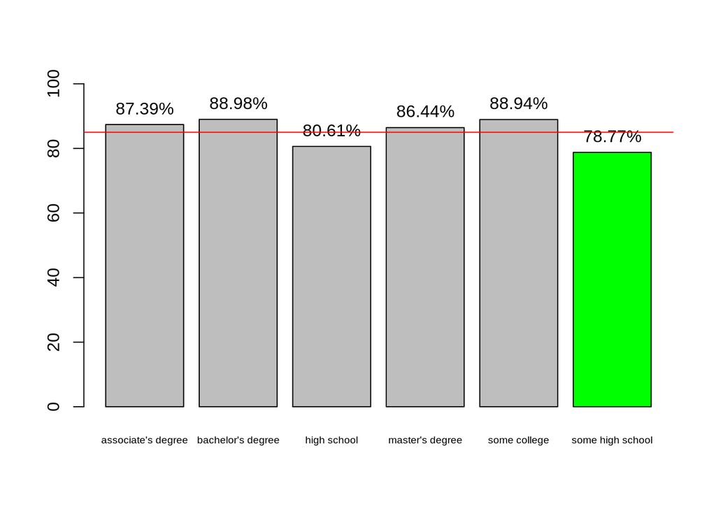

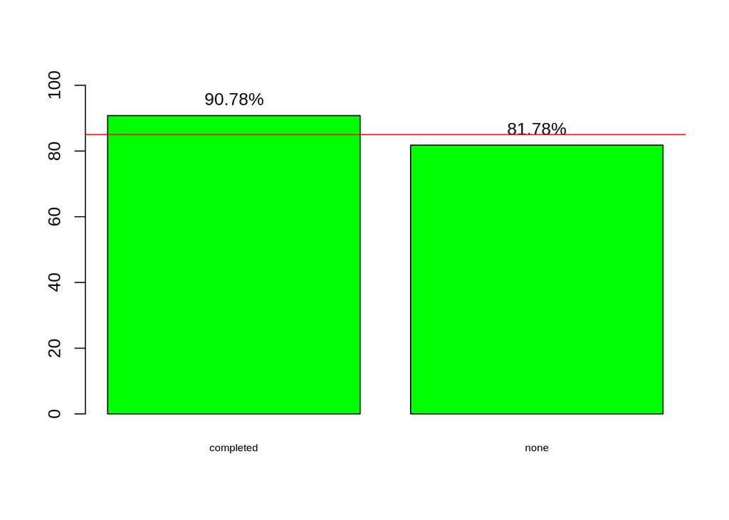

#### 5.2.1.1 Data Splitting Block

Although the ML library imported already includes the dataset splitting funtions during the network trainning procesess, in order to carry out further validation analysis we wil split the dataset despite of its small size.

```r
index <- sample(1:nrow(students_dataC),round(0.8*nrow(students_dataC)))
train <- students_dataC[index,]
test <- students_dataC[-index,]


x_train <- train[, -which(names(train) %in% c("pass"))]
y_train<-train$pass

x_train_mtrx <-  data.matrix(dummy.data.frame(x_train))
y_train_mtrx <-data.matrix(y_train)
```

### 5.2.2 Model Development Block (Pass, Not Pass)

We design under keras framework a network for a Binary clasification model with two hidden layers with relu activation function an finally a sigmoid function able to model outputs within de [0,1] interval, the outputs of the binary classificator.We compile the network aiming to minimice the rmspropop with a binary crossentropy loss function.

```r
model <- keras_model_sequential() %>%
  layer_dense(units = 40, activation = "relu",
              input_shape = dim(x_train_mtrx)[[2]]) %>%
  layer_dense(units = 40, activation = "relu") %>%
  layer_dense(units = 1, activation = "sigmoid")
summary(model)
```

```
## ___________________________________________________________________________
## Layer (type)                     Output Shape                  Param #
## ===========================================================================
## dense_5 (Dense)                  (None, 40)                    840
## ___________________________________________________________________________
## dense_6 (Dense)                  (None, 40)                    1640
## ___________________________________________________________________________
## dense_7 (Dense)                  (None, 1)                     41
## ===========================================================================
## Total params: 2,521
## Trainable params: 2,521
## Non-trainable params: 0
## ___________________________________________________________________________
```

```r
model %>% compile(
  optimizer = "rmsprop",
  loss = "binary_crossentropy",
  metrics = c("accuracy")
)


history <- model %>% fit(
  x_train_mtrx, y_train_mtrx,
  epochs = 50, batch_size = 128,
  validation_split = 0.2
)
```

### 5.2.3 Evaluation

We evaluate the model taking following accuray performance and its convergence an levels accounted in the evaluation caaried out over test and train samples.

#### 5.2.3.1 Error convergence and overfitting

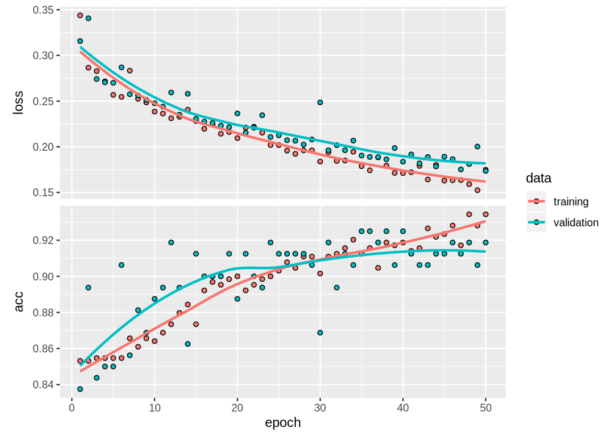

```r
plot(history)
```

```r
#Train Error
model %>% evaluate(x_train_mtrx, y_train_mtrx,verbose = 0)
```

```
## $loss
## [1] 0.156499
##
## $acc
## [1] 0.92375
```

```r
#Test
x_test <- test[, -which(names(test) %in% c("pass"))]
y_test<-test$pass

x_test_mtrx <-  data.matrix(dummy.data.frame(x_test))
y_test_mtrx <-data.matrix(y_test)

#Train Error
model %>% evaluate(x_test_mtrx, y_test_mtrx,verbose = 0)
```

```
## $loss
## [1] 0.1805172
##
## $acc
## [1] 0.915
```

```r
#Visual Exploration
train_2<-NULL
test_2<-NULL

predictions <- model %>% predict(x_train_mtrx)
train_2 <- cbind(train,as.data.frame(predictions))
train_2$sample <- "train"
predictions <- model %>% predict(x_test_mtrx)
test_2<-cbind(test,as.data.frame(predictions))
test_2$sample <- "test"

students_f <-rbind(train_2,test_2)
table(students_f$pass)
```

```
##
##   0   1
## 150 850
```

#### 5.2.3.2 ROC & AUC (Aurea uder the Curve)

```r
#Train
students_f <-train_2
ALPHA=0.5
# Confussion Matrix Train Sample
Confusion_Test=table(students_f$pass,students_f$V1>= ALPHA)
Confusion_Test
```

```
##
##     FALSE TRUE
##   0    67   53
##   1     8  672
```

```r
# Accuracy Train Sample
Accuracy_Test= (sum(students_f$pass==1 & students_f$V1>=ALPHA)+sum(students_f$pass==0 & students_f$V1<ALPHA))/length(students_f$pass)
Accuracy_Test
```

```
## [1] 0.92375
```

```r
# Precission Test Sample
Precision_Test=sum(students_f$pass==1 & students_f$V1>=ALPHA)/sum(students_f$V1>=ALPHA)
Precision_Test
```

```
## [1] 0.9268966
```

```r
# Coverage Train Sample
Cobertura_Test=sum(students_f$pass==1 & students_f$V1>=ALPHA)/sum(students_f$pass==1)
Cobertura_Test
```

```
## [1] 0.9882353
```

```r
#Test
students_f <-test_2
ALPHA=0.5
# Confussion Matrix Test Sample
Confusion_Test=table(students_f$pass,students_f$V1>= ALPHA)
Confusion_Test
```

```
##
##     FALSE TRUE
##   0    13   17
##   1     0  170
```

```r
# Accuracy Test Sample
Accuracy_Test= (sum(students_f$pass==1 & students_f$V1>=ALPHA)+sum(students_f$pass==0 & students_f$V1<ALPHA))/length(students_f$pass)
Accuracy_Test
```

```
## [1] 0.915
```

```r
# Precission Test Sample
Precision_Test=sum(students_f$pass==1 & students_f$V1>=ALPHA)/sum(students_f$V1>=ALPHA)
Precision_Test
```

```
## [1] 0.9090909
```

```r
# Coverage Test Sample
Cobertura_Test=sum(students_f$pass==1 & students_f$V1>=ALPHA)/sum(students_f$pass==1)
Cobertura_Test
```

```
## [1] 1
```

**net/net**As we observe we find main confussion KPIs, anologous between test and train sample, such convergence delivers a good classification model fitting metrics, as the models works with similar performance for different samples to the trainig sample.

- Accuracy : As a metric of clasiffication of both binary options (True Pass, and True Fails) within all the datastes
- Precission : True pass (True Pass, and True Fails) within all the passes predicted by the model.
- Coverage: True pass (True Pass, and True Fails) within all the real pass, as a measure of “reach”

```r
#AUC over Test Sample
auc_test
```

```
## [1] 0.9698039
```

**net/net** An AUC close to 1 is an extraordinary performance metric. AUC under an easy way represents how much a model is capable of distinguish between classes(in this case pass or none pass)

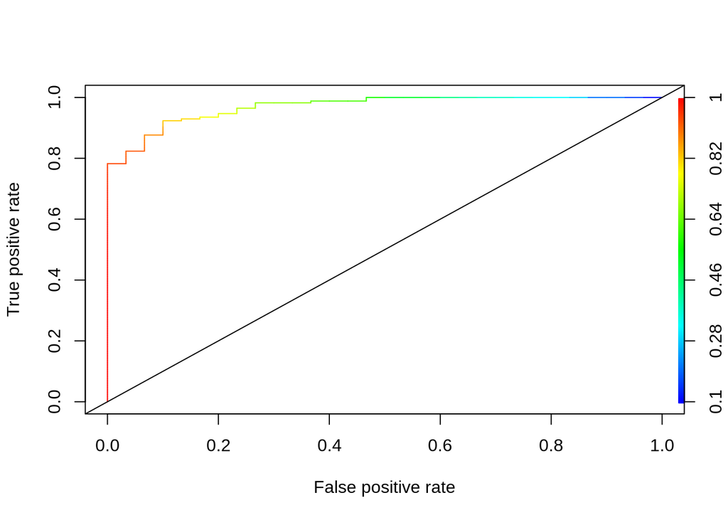